# Single-molecule nucleosome positioning around TSS by Leiden accessibility cluster

Crystal Shan

2026-09-03

FiberHMM nucleosome and TF footprints of single molecules at the early-response promoters and two custom regions, grouped by their m6A accessibility cluster from `leiden_manhattan.Rmd` (Leiden + Manhattan, all four LPS timepoints pooled) and oriented to the GENCODE canonical TSS. Every region is plotted on exactly the window it was clustered on: canonical TSS +/- 1000 bp for the promoters, the region itself for the custom regions. Questions:

1. Do the Leiden accessibility clusters have distinct single-molecule nucleosome configurations? (read-level tracks, per-cluster occupancy)
2. Within a cluster, do the -1 / +1 nucleosome positions move across the LPS time course? (positional summaries, timepoint bars in the tracks)

Processing functions: `process_nuc_pos.R`; plots: `plot_nuc_pos.R`; cluster assignments: `clustering_TSS_methods/Leiden_Manhattan/leiden_manhattan.Rmd` (window_size = 0, Manhattan distance, k = 10, resolution = 1, seed = 1). Nucleosome positions are never used for clustering: accessibility defines the states, the footprints describe them.

# 1. Libraries and source files

```r
library(data.table)
library(ggplot2)
library(cowplot)

source("/project/spott/cshan/fiber-seq/code/nucleosome_positioning/process_nuc_pos.R")
source("/project/spott/cshan/fiber-seq/code/nucleosome_positioning/plot_nuc_pos.R")
```

# 2. Settings

```r
options(scipen = 999)

promoter_table <- "/project/spott/cshan/fiber-seq/macrophage_project/clustering_TSS_methods/hamming_hierarchical/promoter_regions_gencode_v49.tsv"

# Leiden + Manhattan outputs (leiden_manhattan.Rmd): the run to use is the one
# whose run_parameters match these values and the region's window -- unbinned
# m6A sites, k = 10, resolution = 1, all four timepoints pooled.
leiden_dir    <- "/project/spott/cshan/fiber-seq/macrophage_project/clustering_TSS_methods/Leiden_Manhattan"
leiden_params <- list(window_size = 0L, k_neighbors = 10, resolution = 1, seed = 1)

out_dir   <- "/project/spott/cshan/fiber-seq/macrophage_project/nucleosome_positioning/results"
table_dir <- file.path(out_dir, "tables")
plot_dir  <- file.path(out_dir, "plots")
for (d in c(table_dir, plot_dir)) dir.create(d, recursive = TRUE, showWarnings = FALSE)
# the figure files of the knitted html go under results/plots as well, so
# nothing is written next to this Rmd
knitr::opts_chunk$set(fig.path = file.path(plot_dir, "html", ""))

# analysis constants (defined in process_nuc_pos.R)
data.frame(gencode_tss = GENCODE_TSS_PATH, view_half_width = VIEW_HALF_WIDTH,
           profile_bin_bp = PROFILE_BIN_BP)
```

```
##                                                             gencode_tss
## 1 /project/spott/cshan/annotations/gencodev46_Ensembl_canonical_TSS.bed
##   view_half_width profile_bin_bp
## 1            1000             10
```

# 3. Regions

The 8 early-response promoters from `make_promoter_table.R` (genes, ENSG and strand; region_id = gene, IL8 = GENCODE CXCL8) plus the two custom coordinate regions, as in `leiden_manhattan.Rmd`.

```r
promoters <- load_promoter_table(promoter_table)
promoters
```

```
##      gene gencode_name               ensg    chr     start       end       tss
##    <char>       <char>             <char> <char>     <int>     <int>     <int>
## 1:   IL1B         IL1B ENSG00000125538.12   chr2 112835816 112837816 112836816
## 2:    TNF          TNF  ENSG00000232810.5   chr6  31574565  31576565  31575565
## 3:   IL1A         IL1A  ENSG00000115008.7   chr2 112783493 112785493 112784493
## 4:  PTGS2        PTGS2 ENSG00000073756.13   chr1 186679922 186681922 186680922
## 5:    IL8        CXCL8 ENSG00000169429.13   chr4  73739519  73741519  73740519
## 6:  CXCL2        CXCL2 ENSG00000081041.10   chr4  74098196  74100196  74099196
## 7:    IL6          IL6 ENSG00000136244.13   chr7  22724884  22726884  22725884
## 8:   RELB         RELB ENSG00000104856.15  chr19  45000461  45002461  45001461
##    gene_start  gene_end gene_strand       ensg_base
##         <int>     <int>      <char>          <char>
## 1:  112829751 112836816           - ENSG00000125538
## 2:   31575565  31578336           + ENSG00000232810
## 3:  112773925 112784493           - ENSG00000115008
## 4:  186671791 186680922           - ENSG00000073756
## 5:   73740519  73747379           + ENSG00000169429
## 6:   74097040  74099196           - ENSG00000081041
## 7:   22725884  22732002           + ENSG00000136244
## 8:   45001461  45038192           + ENSG00000104856
```

```r
custom <- data.frame(
  chr = c("chr4", "chr5"),
  start = c(112284963, 150068577),
  end = c(112285236, 150068792)
)
custom$region_id <- paste(custom$chr, custom$start, custom$end, sep = "_")

regions <- rbind(
  data.frame(chr = promoters$chr, start = promoters$start, end = promoters$end,
             region_id = promoters$gene),
  custom
)
regions
```

```
##      chr     start       end                region_id
## 1   chr2 112835816 112837816                     IL1B
## 2   chr6  31574565  31576565                      TNF
## 3   chr2 112783493 112785493                     IL1A
## 4   chr1 186679922 186681922                    PTGS2
## 5   chr4  73739519  73741519                      IL8
## 6   chr4  74098196  74100196                    CXCL2
## 7   chr7  22724884  22726884                      IL6
## 8  chr19  45000461  45002461                     RELB
## 9   chr4 112284963 112285236 chr4_112284963_112285236
## 10  chr5 150068577 150068792 chr5_150068577_150068792
```

# 4. GENCODE canonical TSS annotation and windows

Promoters are anchored on the GENCODE v46 Ensembl-canonical TSS of their ENSG (TSS = 0, upstream negative, mirrored for minus-strand genes); their window (`view_start`-`view_end`) is the canonical TSS +/- 1000 bp clustered in `leiden_manhattan.Rmd`. `tss_offset` is the distance from the promoter table’s own TSS (the v49 gene 5’ end) to the canonical TSS in the direction of transcription. The custom regions are anchored on their centre and their window is the region itself.

```r
gencode_tss <- load_gencode_tss()
head(gencode_tss)
```

```
##     chrom   tss strand           gene_id            ensg     transcript_id
##    <char> <int> <char>            <char>          <char>            <char>
## 1:   chr1 11869      + ENSG00000290825.1 ENSG00000290825 ENST00000456328.2
## 2:   chr1 12010      + ENSG00000223972.6 ENSG00000223972 ENST00000450305.2
## 3:   chr1 17436      - ENSG00000278267.1 ENSG00000278267 ENST00000619216.1
## 4:   chr1 24886      - ENSG00000227232.6 ENSG00000227232 ENST00000488147.2
## 5:   chr1 29554      + ENSG00000243485.5 ENSG00000243485 ENST00000473358.1
## 6:   chr1 30366      + ENSG00000284332.1 ENSG00000284332 ENST00000607096.1
##      gene_name                          gene_type
##         <char>                             <char>
## 1:     DDX11L2                             lncRNA
## 2:     DDX11L1 transcribed_unprocessed_pseudogene
## 3:   MIR6859-1                              miRNA
## 4:      WASH7P             unprocessed_pseudogene
## 5: MIR1302-2HG                             lncRNA
## 6:   MIR1302-2                              miRNA
##                                                         transcript_tags
##                                                                  <char>
## 1:                                              basic,Ensembl_canonical
## 2:                                              basic,Ensembl_canonical
## 3:                                              basic,Ensembl_canonical
## 4:                                              basic,Ensembl_canonical
## 5: dotter_confirmed,not_best_in_genome_evidence,basic,Ensembl_canonical
## 6:                                              basic,Ensembl_canonical
```

```r
anchors <- build_region_anchors(regions, promoters, gencode_tss)
anchors
```

```
##                    region_id region_type    chr     start       end   gene
##                       <char>      <char> <char>     <int>     <int> <char>
##  1:                     IL1B    promoter   chr2 112835816 112837816   IL1B
##  2:                      TNF    promoter   chr6  31574565  31576565    TNF
##  3:                     IL1A    promoter   chr2 112783493 112785493   IL1A
##  4:                    PTGS2    promoter   chr1 186679922 186681922  PTGS2
##  5:                      IL8    promoter   chr4  73739519  73741519    IL8
##  6:                    CXCL2    promoter   chr4  74098196  74100196  CXCL2
##  7:                      IL6    promoter   chr7  22724884  22726884    IL6
##  8:                     RELB    promoter  chr19  45000461  45002461   RELB
##  9: chr4_112284963_112285236      custom   chr4 112284963 112285236   <NA>
## 10: chr5_150068577_150068792      custom   chr5 150068577 150068792   <NA>
##     gencode_name            ensg strand    anchor             anchor_source
##           <char>          <char> <char>     <int>                    <char>
##  1:         IL1B ENSG00000125538      - 112836779 GENCODE v46 canonical TSS
```

[output cut: 33 more lines]

```r
fwrite(anchors, file.path(table_dir, "region_anchors.tsv"), sep = "\t")
```

# 5. Load Leiden assignments

One cluster label per read from the pooled-timepoint run of each region (`<region_id>/bin0/k<n>/read_cluster_assignments_<region_id>.tsv`, the run whose parameters and window match section 4), with region_id added. Read spans are kept: they are the denominators of the occupancy profiles and the baselines of the read tracks.

```r
assignments <- load_leiden_assignments(leiden_dir, anchors, leiden_params)
reads <- build_read_table(assignments, anchors)

dcast(reads[, .N, by = .(region_id, timepoint)], region_id ~ timepoint, value.var = "N")
```

```
## Key: <region_id>
##                    region_id     0     5    10    15
##                       <char> <int> <int> <int> <int>
##  1:                    CXCL2    36    59    56    64
##  2:                     IL1A    45    37    63    47
##  3:                     IL1B    37    41    57    40
##  4:                      IL6    34    39    50    45
##  5:                      IL8    49    44    59    55
##  6:                    PTGS2    77    87    77    81
##  7:                     RELB    32    45    39    29
##  8:                      TNF    21    21    27    31
##  9: chr4_112284963_112285236    44    48    44    64
## 10: chr5_150068577_150068792    38    51    52    51
```

```r
dcast(reads[, .N, by = .(region_id, cluster)], region_id ~ cluster, value.var = "N", fill = 0)
```

```
## Key: <region_id>
##                    region_id cluster1 cluster2 cluster3 cluster4 cluster5
##                       <char>    <int>    <int>    <int>    <int>    <int>
##  1:                    CXCL2       61       48       45       42       19
##  2:                     IL1A       83       78       31        0        0
##  3:                     IL1B       69       43       33       30        0
##  4:                      IL6       64       57       47        0        0
##  5:                      IL8       71       71       65        0        0
##  6:                    PTGS2       56       55       52       47       39
##  7:                     RELB       40       33       30       23       11
##  8:                      TNF       40       34       26        0        0
##  9: chr4_112284963_112285236       45       34       34       32       31
## 10: chr5_150068577_150068792       46       35       30       29       27
##     cluster6 cluster7
##        <int>    <int>
##  1:        0        0
##  2:        0        0
##  3:        0        0
##  4:        0        0
##  5:        0        0
##  6:       38       35
##  7:        8        0
##  8:        0        0
##  9:       24        0
## 10:       25        0
```

# 6. Extract nucleosome footprints

All FiberHMM nucleosome footprints (every block of the footprint BED12, no size filter) and the three TF footprint size classes for every clustered read, from each read’s own sample BED, RID preserved. One row per footprint, in genomic (BED) and anchor-relative coordinates.

```r
footprints <- extract_region_footprints(reads, anchors)
```

```
## IL1B                        175 reads   1079 nucleosome    363 TF footprints
```

```
## TNF                         100 reads    643 nucleosome    131 TF footprints
```

```
## IL1A                        192 reads   1204 nucleosome    273 TF footprints
```

```
## PTGS2                       322 reads   2039 nucleosome    571 TF footprints
```

```
## IL8                         207 reads   1274 nucleosome    413 TF footprints
```

```
## CXCL2                       215 reads   1476 nucleosome    317 TF footprints
```

```
## IL6                         168 reads   1022 nucleosome    189 TF footprints
```

```
## RELB                        145 reads    914 nucleosome    447 TF footprints
```

```
## chr4_112284963_112285236    200 reads    308 nucleosome     84 TF footprints
```

```
## chr5_150068577_150068792    192 reads    288 nucleosome     37 TF footprints
```

```r
dcast(footprints[, .N, by = .(region_id, fp_class)], region_id ~ fp_class,
      value.var = "N", fill = 0)
```

```
## Key: <region_id>
##                    region_id nucleosome tf_10-30 tf_40-60 tf_60-80
##                       <char>      <int>    <int>    <int>    <int>
##  1:                    CXCL2       1476      253       50       14
##  2:                     IL1A       1204      248       17        8
##  3:                     IL1B       1079      324       24       15
##  4:                      IL6       1022      123       48       18
##  5:                      IL8       1274      359       41       13
##  6:                    PTGS2       2039      475       57       39
##  7:                     RELB        914      280       99       68
##  8:                      TNF        643      105       13       13
##  9: chr4_112284963_112285236        308       68       10        6
## 10: chr5_150068577_150068792        288       30        2        5
```

# 7. Join footprints to Leiden clusters

```r
footprints <- merge(footprints,
                    reads[, .(region_id, RID, sample_name, timepoint, cluster, gene, ensg)],
                    by = c("region_id", "RID", "sample_name"))
setcolorder(footprints, c("region_id", "gene", "ensg", "RID", "sample_name", "timepoint",
                          "cluster", "fp_class", "fp_start", "fp_end", "fp_mid",
                          "rel_start", "rel_end", "rel_mid", "fp_size"))
head(footprints)
```

```
## Key: <region_id, RID, sample_name>
##    region_id   gene            ensg                                   RID
##       <char> <char>          <char>                                <char>
## 1:     CXCL2  CXCL2 ENSG00000081041 m84241_260505_182714_s3/120329826/ccs
## 2:     CXCL2  CXCL2 ENSG00000081041 m84241_260505_182714_s3/120329826/ccs
## 3:     CXCL2  CXCL2 ENSG00000081041 m84241_260505_182714_s3/120329826/ccs
## 4:     CXCL2  CXCL2 ENSG00000081041 m84241_260505_182714_s3/120329826/ccs
## 5:     CXCL2  CXCL2 ENSG00000081041 m84241_260505_182714_s3/120329826/ccs
## 6:     CXCL2  CXCL2 ENSG00000081041 m84241_260505_182714_s3/120329826/ccs
##    sample_name timepoint  cluster   fp_class fp_start   fp_end   fp_mid
##         <char>    <fctr>   <fctr>     <char>    <int>    <int>    <num>
## 1:       LPS_5         5 cluster1 nucleosome 74098175 74098677 74098426
## 2:       LPS_5         5 cluster1 nucleosome 74098686 74098819 74098753
## 3:       LPS_5         5 cluster1 nucleosome 74098842 74099003 74098923
## 4:       LPS_5         5 cluster1 nucleosome 74099131 74099288 74099210
## 5:       LPS_5         5 cluster1 nucleosome 74099453 74100596 74100025
## 6:       LPS_5         5 cluster1   tf_10-30 74099380 74099392 74099386
##    rel_start rel_end rel_mid fp_size
##        <int>   <int>   <num>   <int>
## 1:       518    1019   768.5     502
## 2:       376     508   442.0     133
## 3:       192     352   272.0     161
## 4:       -93      63   -15.0     157
## 5:     -1401    -259  -830.0    1143
## 6:      -197    -186  -191.5      12
```

```r
# per-read positional summary (-1 / +1 nucleosome, NFR width, anchor occupied)
read_positions <- read_position_summary(footprints, reads)
head(read_positions)
```

```
##    region_id                                   RID   gene sample_name timepoint
##       <char>                                <char> <char>      <char>    <fctr>
## 1:     CXCL2 m84241_260505_203017_s4/102502771/ccs  CXCL2       LPS_0         0
## 2:     CXCL2  m84241_260505_203017_s4/68358095/ccs  CXCL2       LPS_0         0
## 3:     CXCL2 m84241_260613_000051_s2/106040976/ccs  CXCL2       LPS_0         0
## 4:     CXCL2 m84241_260613_000051_s2/206767915/ccs  CXCL2       LPS_0         0
## 5:     CXCL2  m84241_260613_000051_s2/34275500/ccs  CXCL2       LPS_0         0
## 6:     CXCL2  m84241_260613_000051_s2/50070983/ccs  CXCL2       LPS_0         0
##     cluster minus1_mid minus1_end plus1_mid plus1_start anchor_occupied n_nuc
##      <fctr>      <num>      <int>     <num>       <int>          <lgcl> <int>
## 1: cluster1      -40.0         30     387.5         288            TRUE     9
## 2: cluster1      -26.0         41     340.0         197            TRUE     6
## 3: cluster1      -54.5          1     266.0         192            TRUE     8
## 4: cluster1      -25.5         41     512.5         251            TRUE     5
## 5: cluster1     -372.5       -320      31.0         -24            TRUE    10
## 6: cluster1      -71.5        -57     387.5         319           FALSE     8
##    nfr_width
##        <num>
## 1:       257
## 2:       155
## 3:       190
## 4:       209
## 5:       295
## 6:       375
```

```r
fwrite(reads,          file.path(table_dir, "reads_by_cluster.tsv"), sep = "\t")
fwrite(footprints,     file.path(table_dir, "footprints_by_read.tsv.gz"), sep = "\t")
fwrite(read_positions, file.path(table_dir, "read_position_summary.tsv"), sep = "\t")
```

# 8. Read-level nucleosome and TF footprint plots (Fig 1)

One row per molecule, footprints at their full width, clipped to the window. Rows are grouped by Leiden cluster (facets), then timepoint, then the position of the +1 nucleosome; the bars on the left mark cluster and timepoint.

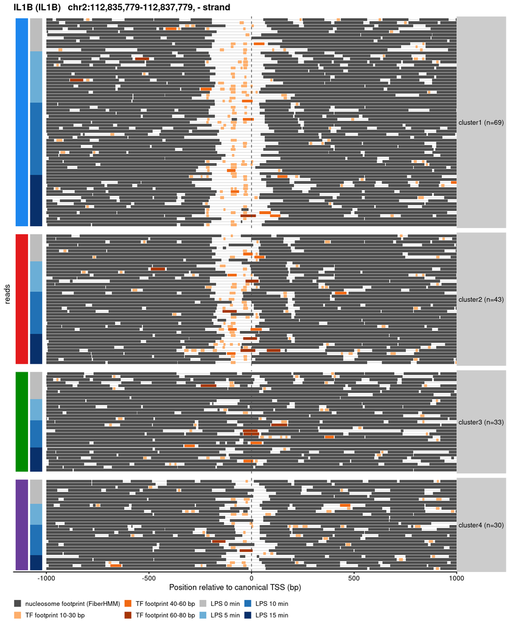

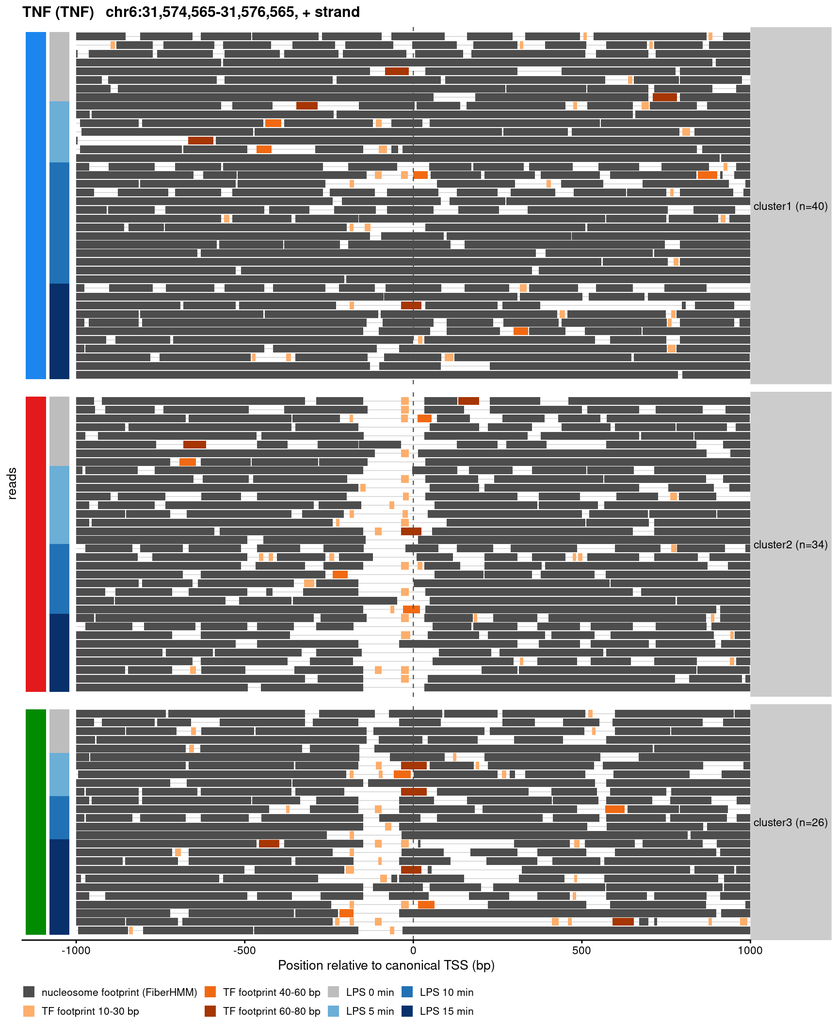

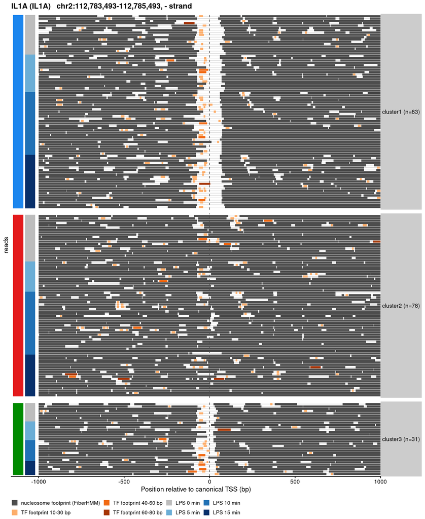

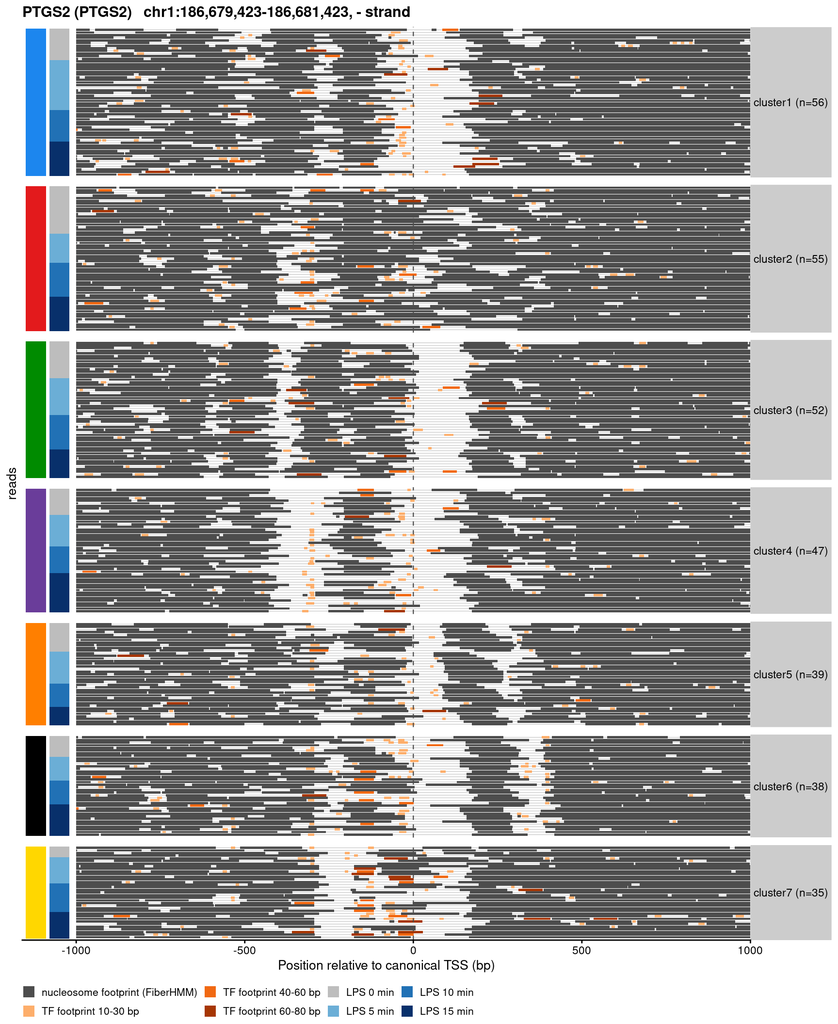

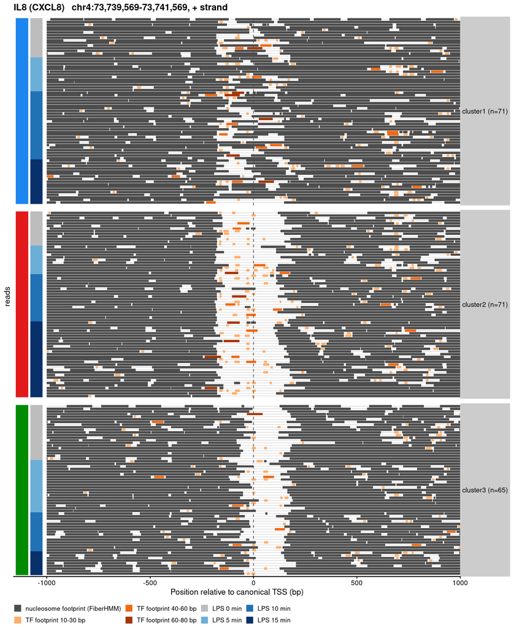

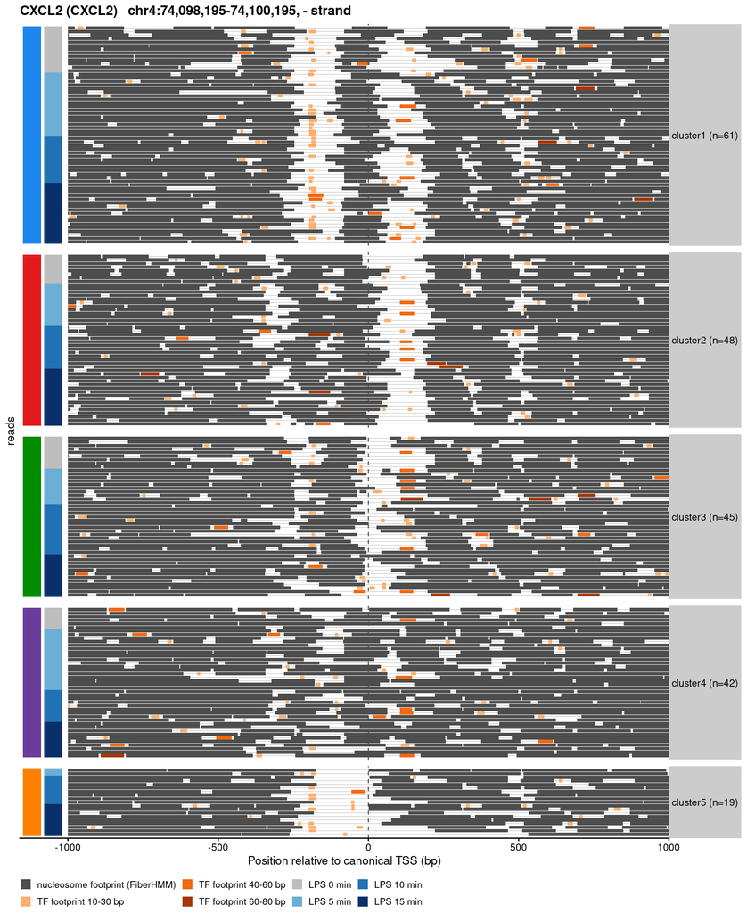

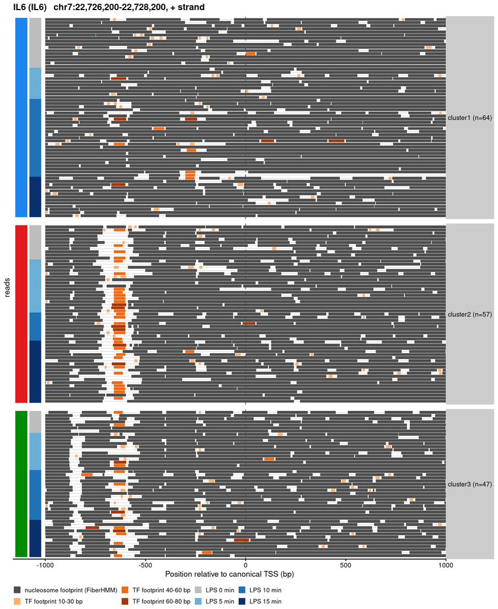

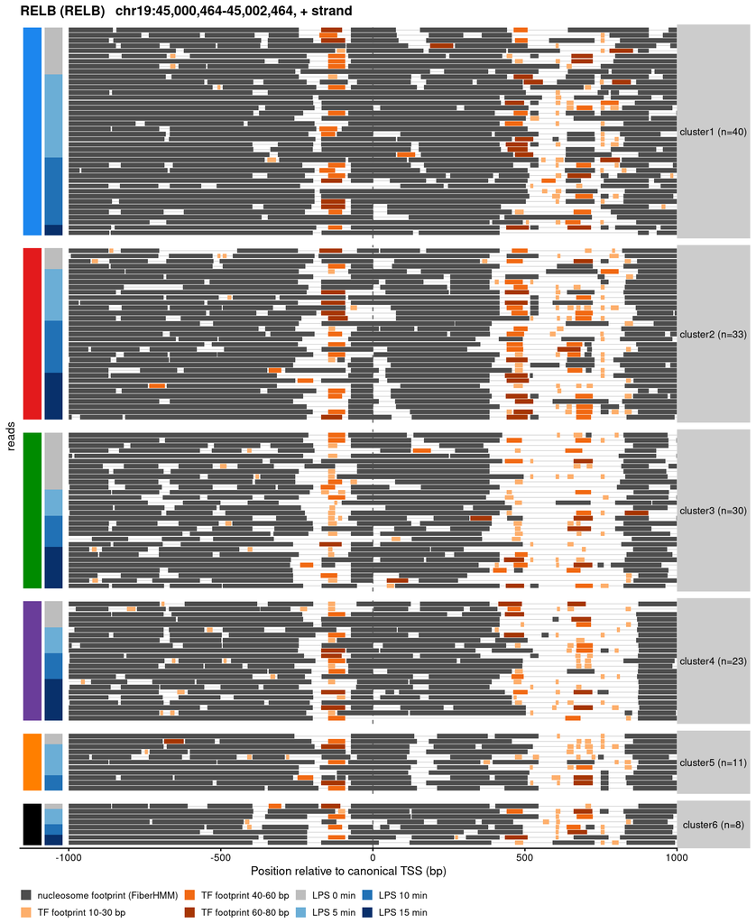

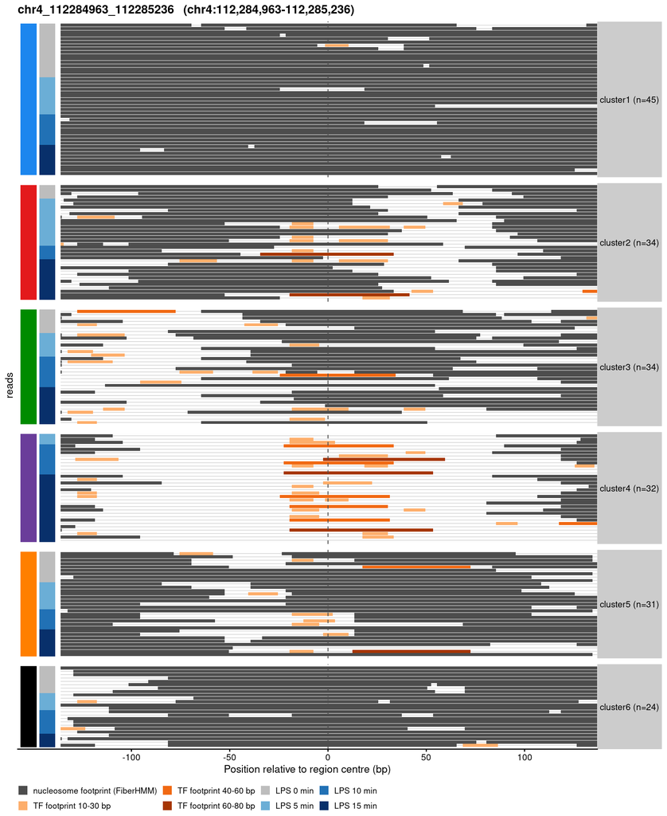

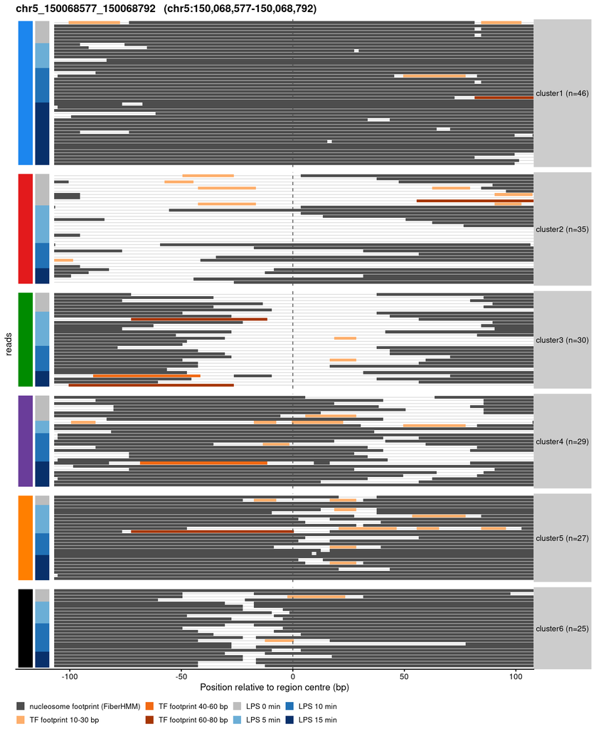

```r
p_reads <- list()
for (rid in anchors$region_id) {
  m       <- anchors[region_id == rid]
  reads_r <- reads[region_id == rid]
  if (!nrow(reads_r)) next
  p_reads[[rid]] <- plot_read_footprints(footprints[region_id == rid], reads_r,
                                         read_positions[region_id == rid], m)
  print(p_reads[[rid]])
  ggsave(file.path(plot_dir, sprintf("%s_fig1_read_footprints.pdf", rid)), p_reads[[rid]],
         width = 9, height = max(5, 0.03 * nrow(reads_r) + 2.5 + 0.3 * uniqueN(reads_r$cluster)),
         limitsize = FALSE)
}
```

# 9. Nucleosome occupancy per cluster (Fig 2)

Fraction of reads with a nucleosome footprint covering each position (10-bp bins; denominator = reads spanning the position), one panel per cluster, timepoints pooled. Distinct profiles = the accessibility states are also distinct nucleosome-positioning states.

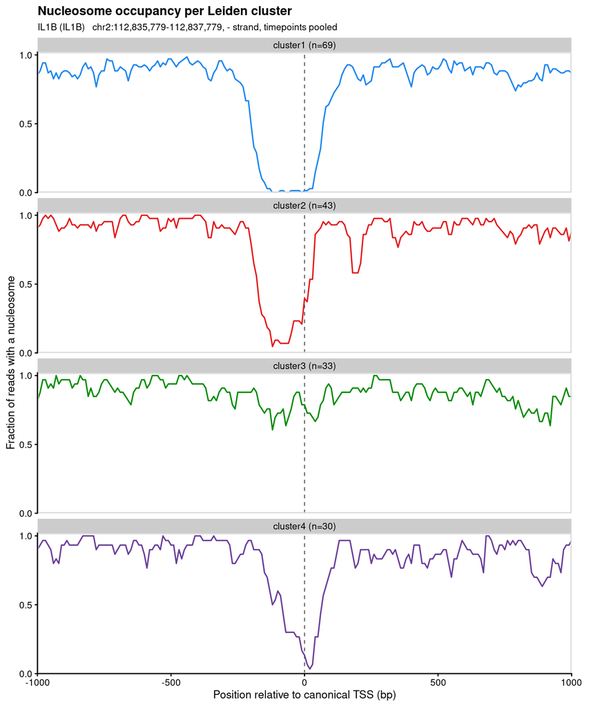

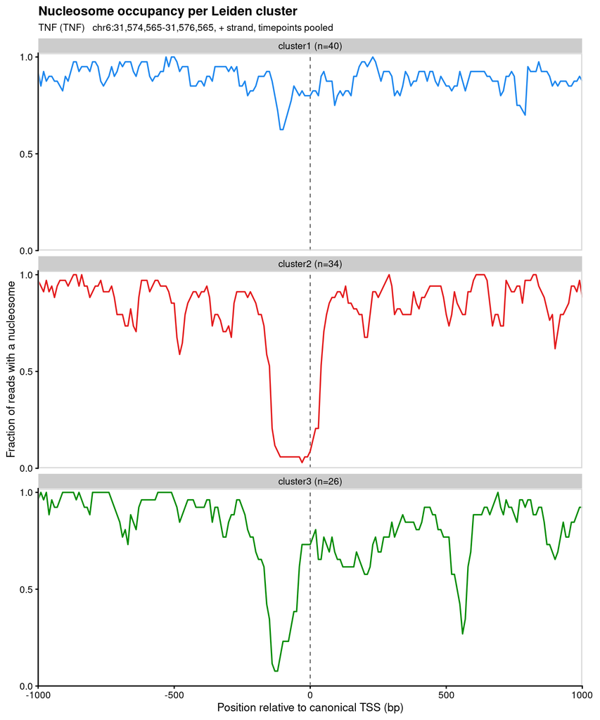

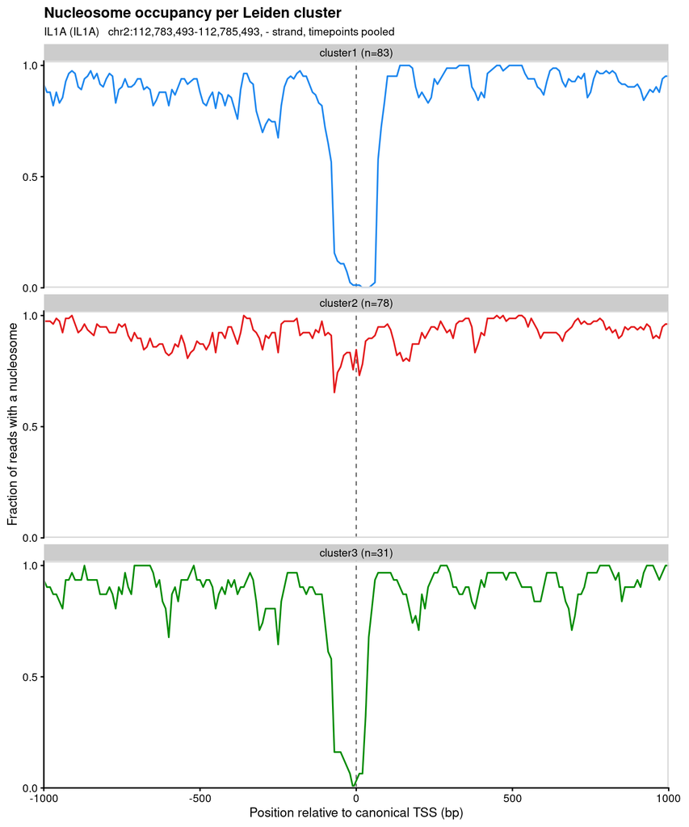

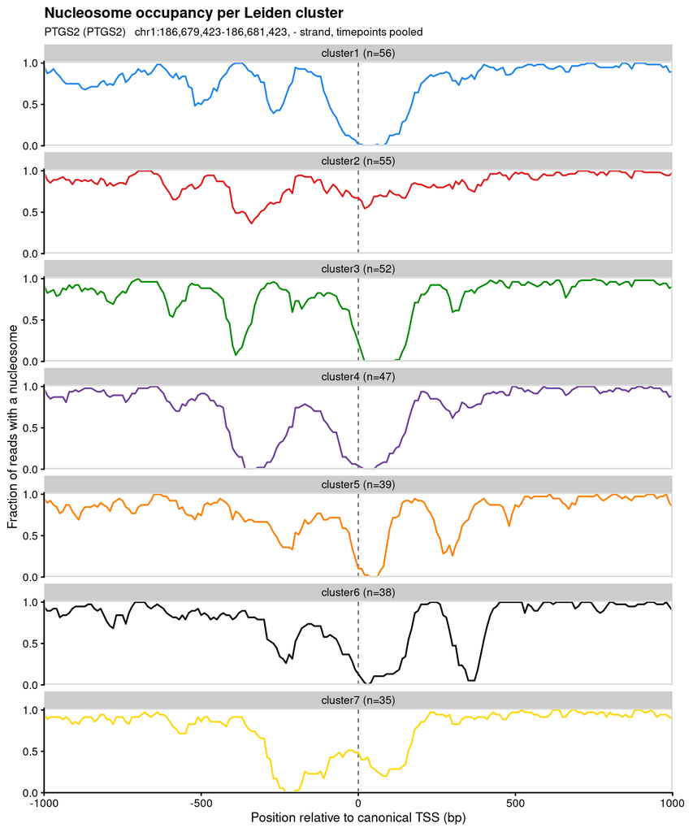

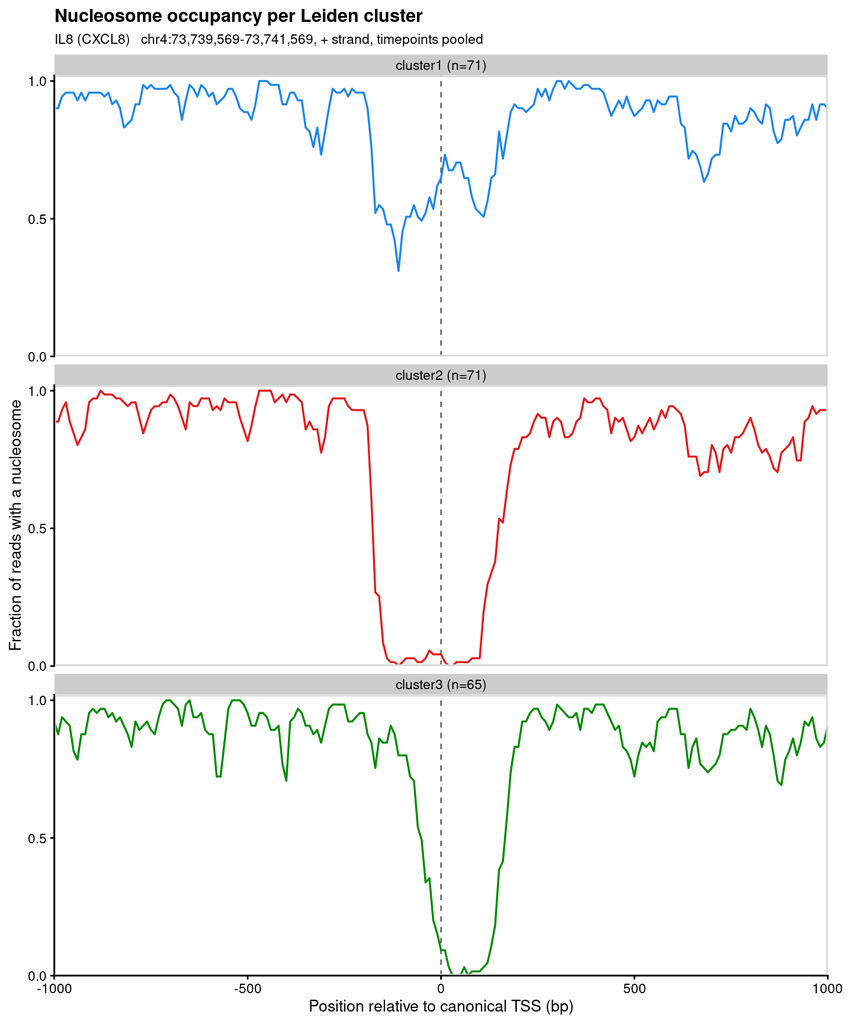

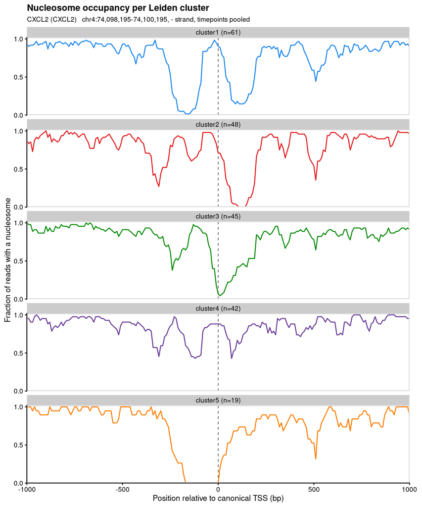

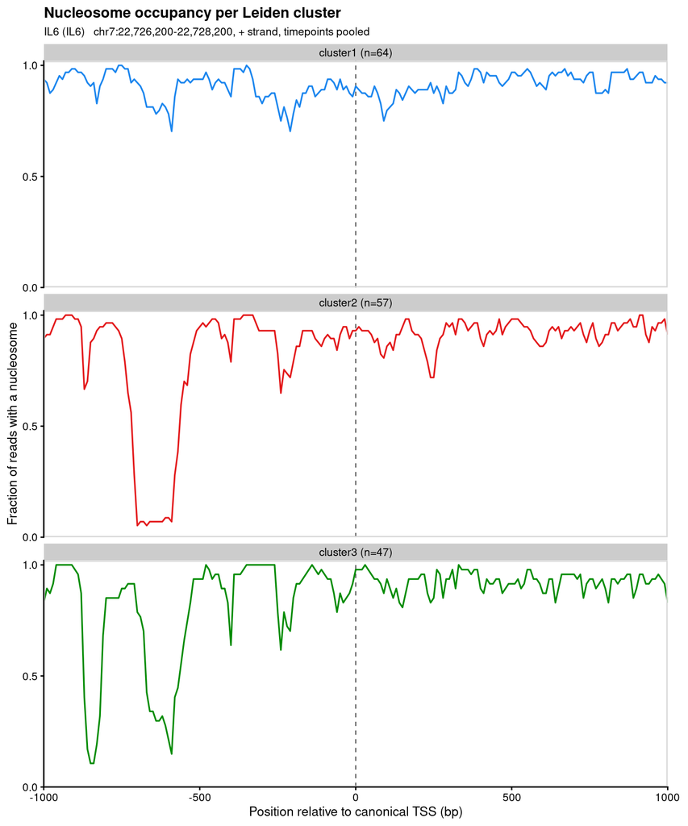

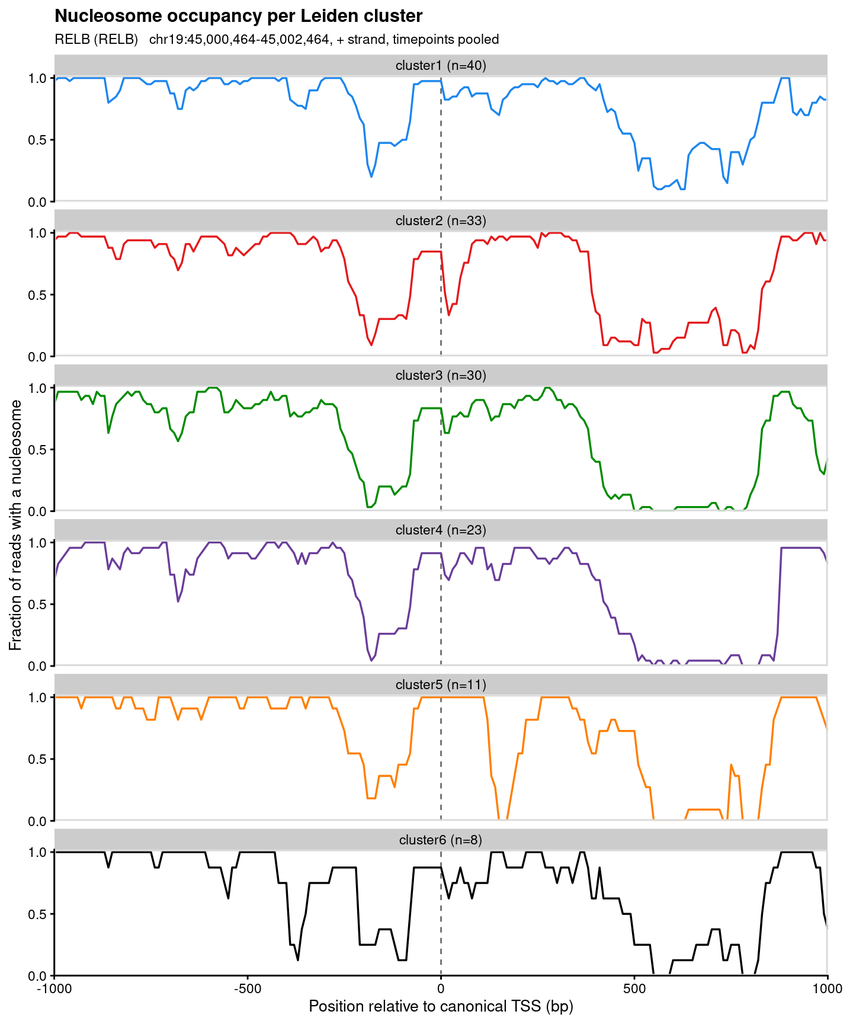

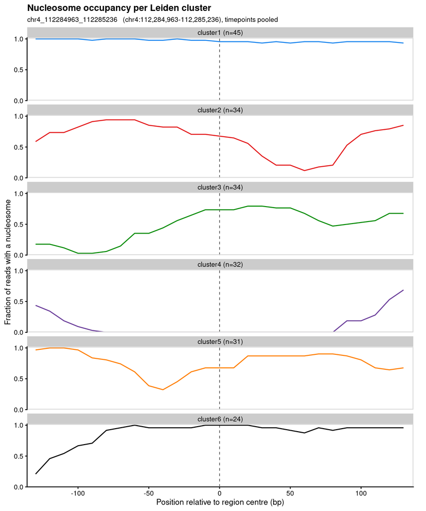

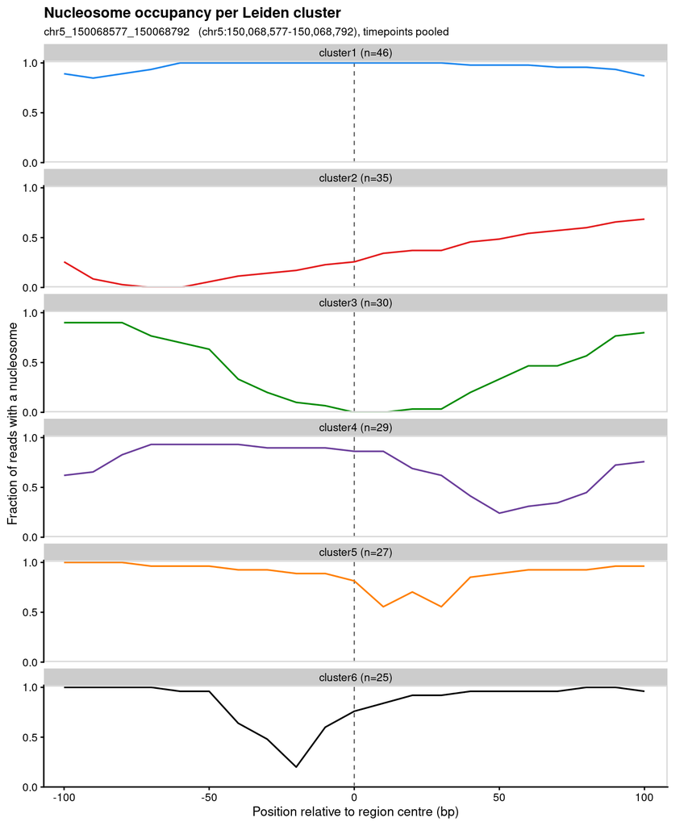

```r
occ_cluster <- occupancy_profile(footprints, reads, anchors, by = c("region_id", "cluster"))
fwrite(occ_cluster, file.path(table_dir, "occupancy_by_cluster.tsv"), sep = "\t")

for (rid in names(p_reads)) {
  reads_r <- reads[region_id == rid]
  p <- plot_occupancy_by_cluster(occ_cluster[region_id == rid], reads_r, anchors[region_id == rid])
  print(p)
  ggsave(file.path(plot_dir, sprintf("%s_fig2_occupancy_by_cluster.pdf", rid)), p,
         width = 7.5, height = 1.4 * uniqueN(reads_r$cluster) + 1.4)
}
```

# 10. Positional summaries across time

Per read: midpoint of the nearest upstream (-1) and downstream (+1) nucleosome and the gap between them (NFR width), by cluster and timepoint. A shift of a few tens of bp within a cluster is easier to read here than from the tracks.

```r
position_groups <- position_summary_by_group(read_positions)
fwrite(position_groups, file.path(table_dir, "position_summary_by_cluster_timepoint.tsv"),
       sep = "\t")
position_groups
```

```
##                     region_id  cluster timepoint n_reads n_minus1 minus1_median
##                        <char>   <fctr>    <fctr>   <int>    <int>         <num>
##   1:                    CXCL2 cluster1         0      13       13        -42.00
##   2:                    CXCL2 cluster1         5      18       18        -37.50
##   3:                    CXCL2 cluster1        10      13       13        -37.50
##   4:                    CXCL2 cluster1        15      17       17        -21.00
##   5:                    CXCL2 cluster2         0       8        8       -151.25
##  ---
## 177: chr5_150068577_150068792 cluster5        15       8        4        -86.00
## 178: chr5_150068577_150068792 cluster6         0       4        3       -120.50
## 179: chr5_150068577_150068792 cluster6         5       7        7       -106.00
## 180: chr5_150068577_150068792 cluster6        10       9        9       -125.00
## 181: chr5_150068577_150068792 cluster6        15       5        5       -111.00
##      n_plus1 plus1_median nfr_median frac_anchor_occupied
##        <int>        <num>      <num>                <num>
##   1:      13       275.00      189.0            0.8461538
##   2:      18       266.25      135.0            0.9444444
##   3:      13       242.50      163.0            0.8461538
##   4:      17       288.00      156.0            0.9411765
##   5:       8       266.00      209.0            0.2500000
##  ---
## 177:       7       138.50       23.0            1.0000000
## 178:       4        63.50       39.0            0.7500000
## 179:       6        69.75       15.5            1.0000000
## 180:       9        94.00       34.0            0.5555556
## 181:       5       196.00       26.0            0.8000000
```

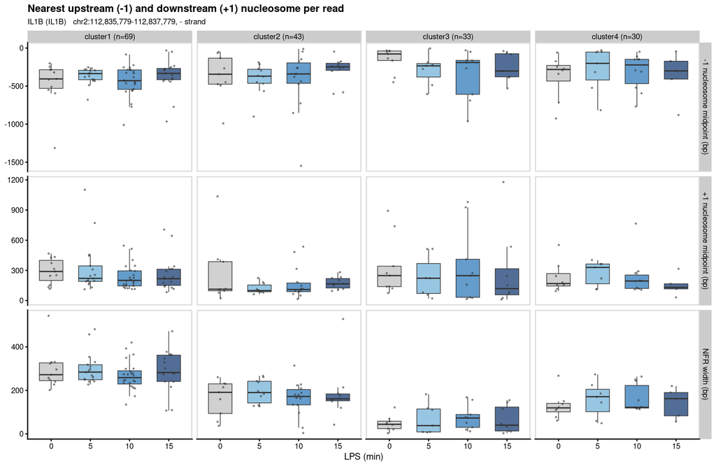

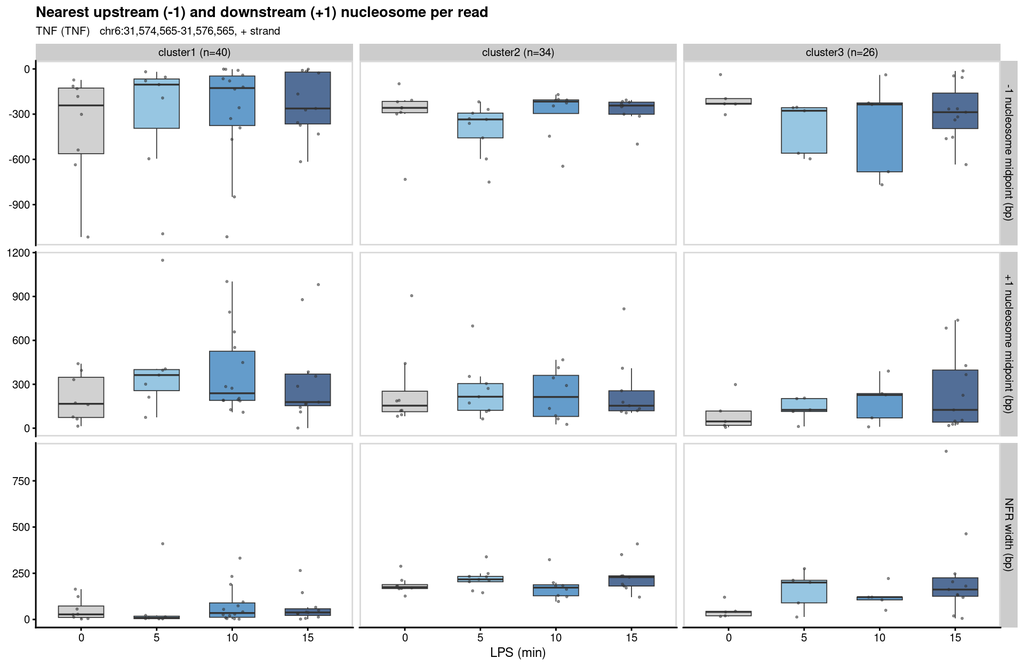

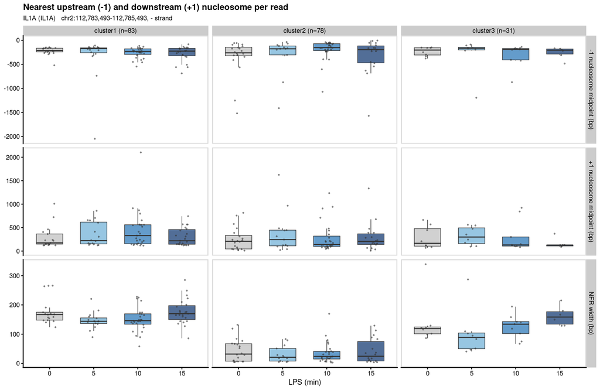

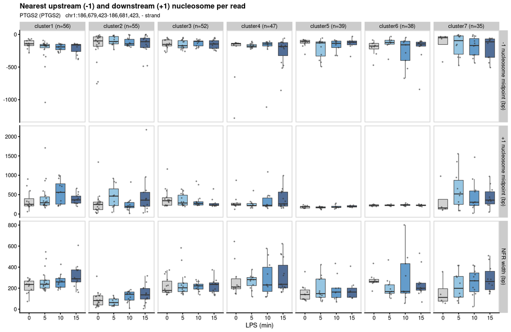

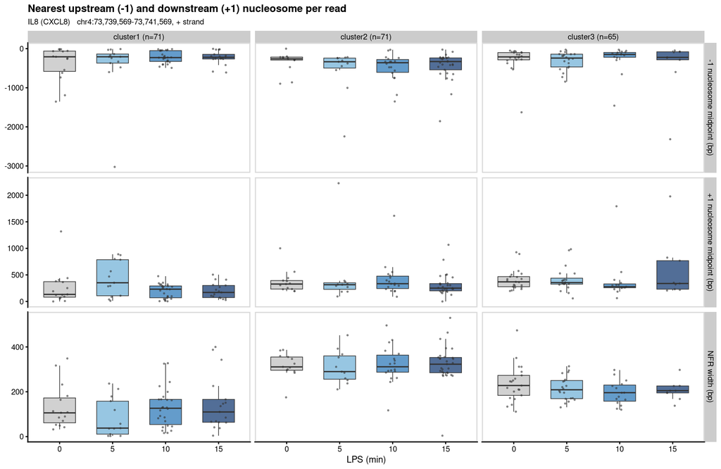

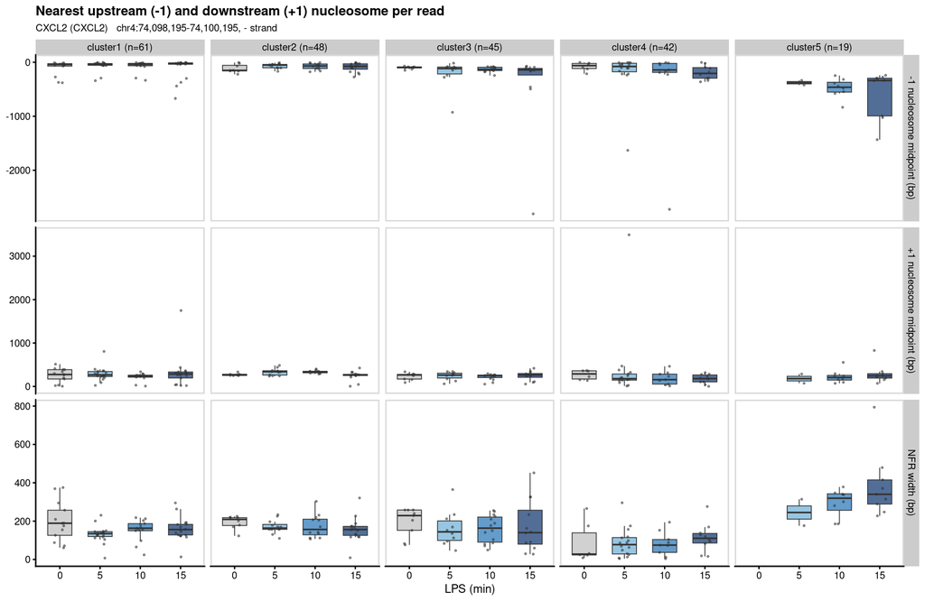

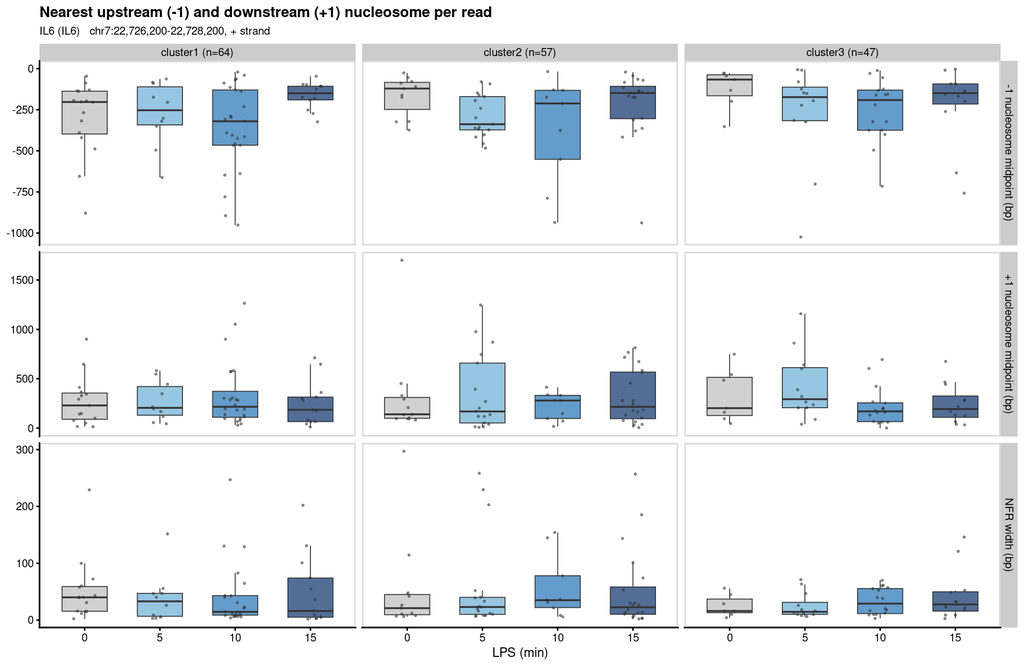

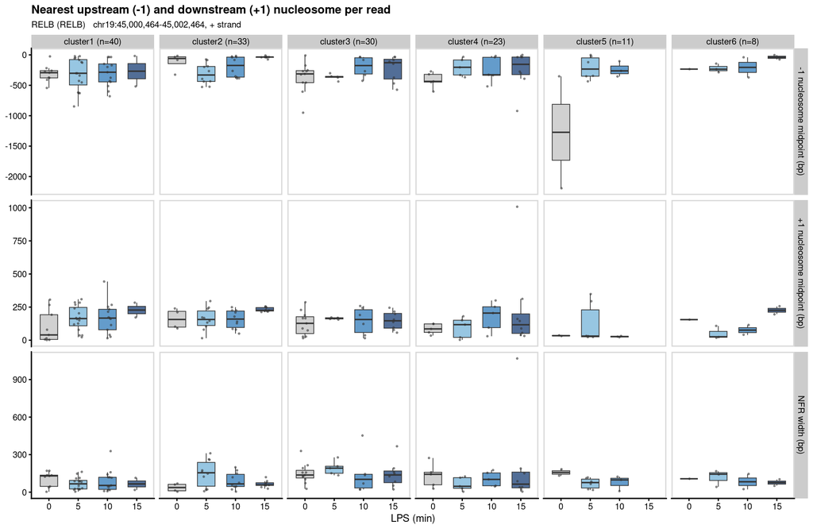

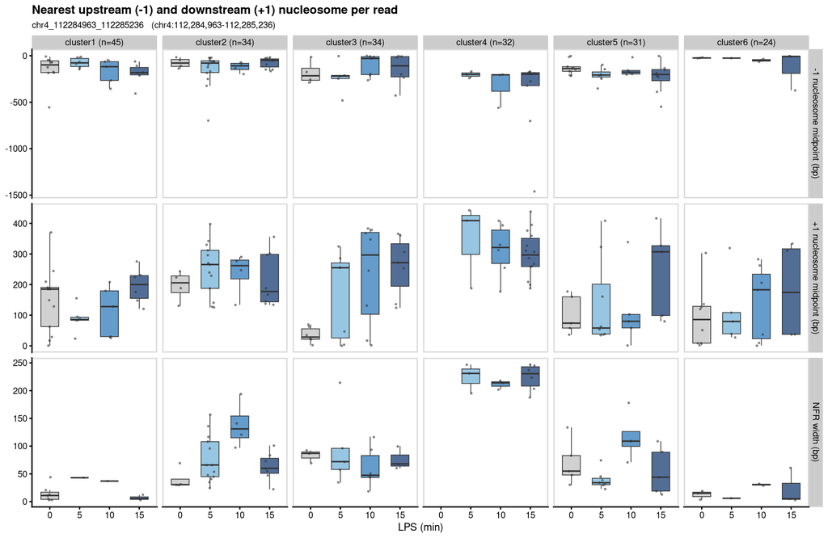

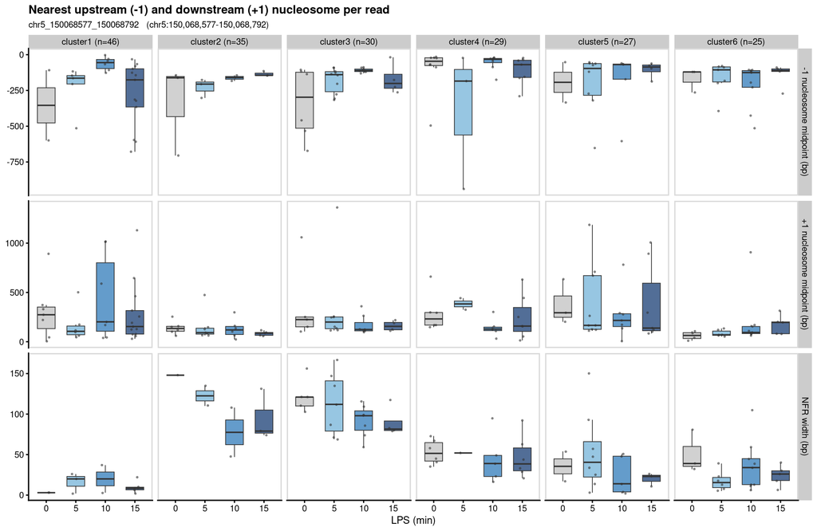

```r
for (rid in names(p_reads)) {
  p <- plot_position_summary(read_positions[region_id == rid], reads[region_id == rid],
                             anchors[region_id == rid])
  print(p)
  ggsave(file.path(plot_dir, sprintf("%s_position_summary.pdf", rid)), p,
         width = 10, height = 6.5)
}
```